# BEA explore

Dr. Burchfield

Last updated: 12 February, 2021

All data downloaded from the BEA [here](https://apps.bea.gov/regional/downloadzip.cfm). Variable descriptions can be found [here](https://apps.bea.gov/regional/definitions/).

BEA region codes:

1. New England (Connecticut, Maine, Massachusetts, New Hampshire, Rhode Island, and Vermont);
2. Mideast (Delaware, District of Columbia, Maryland, New Jersey, New York, and Pennsylvania);
3. Great Lakes (Illinois, Indiana, Michigan, Ohio, and Wisconsin);
4. Plains (Iowa, Kansas, Minnesota, Missouri, Nebraska, North Dakota, and South Dakota);
5. Southeast (Alabama, Arkansas, Florida, Georgia, Kentucky, Louisiana, Mississippi, North Carolina, South Carolina, Tennessee, Virginia, and West Virginia);
6. Southwest (Arizona, New Mexico, Oklahoma, and Texas);
7. Rocky Mountain (Colorado, Idaho, Montana, Utah, and Wyoming); and
8. Far West (Alaska, California, Hawaii, Nevada, Oregon, and Washington).

```r
source("BEA_func.R")
source("BEA_load.R")
```

- CAGDP11 - contributions to percent change in real GDP
- CAGDP1 - GDP summary by county
- CAEMP25N - total full-time and part-time employment by NAICS
- CAEMP25S - total full- and part-time employment by SIC
- CAINC1 - annual personal income by county
- CAINC45 - farm income and expenses
- CAINC4 - personal income and employment by major component
- CAINC5N - personal income by major component by NAICS
- CAINC5S - personal income by major component by SIC
- CAINC6N - compensation of employees by NAICS
- CAINC6S - compensation of employees by SIC
- CAINC30 - economic profile by county

(many more on website to explore)

```r
# aggregate spreadsheets for each category
file_list <- Sys.glob("./data/*ALL_AREAS*.csv")
file_list
```

```
##  [1] "./data/CAEMP25N__ALL_AREAS_2001_2019.csv"
##  [2] "./data/CAEMP25S__ALL_AREAS_1969_2000.csv"
##  [3] "./data/CAGDP11__ALL_AREAS_2002_2019.csv"
##  [4] "./data/CAGDP1__ALL_AREAS_2001_2019.csv"
##  [5] "./data/CAINC1__ALL_AREAS_1969_2019.csv"
##  [6] "./data/CAINC30__ALL_AREAS_1969_2019.csv"
##  [7] "./data/CAINC45__ALL_AREAS_1969_2019.csv"
##  [8] "./data/CAINC4__ALL_AREAS_1969_2019.csv"
##  [9] "./data/CAINC5N__ALL_AREAS_2001_2019.csv"
## [10] "./data/CAINC5S__ALL_AREAS_1969_2000.csv"
## [11] "./data/CAINC6N__ALL_AREAS_2001_2019.csv"
## [12] "./data/CAINC6S__ALL_AREAS_1998_2000.csv"
```

# CAINC45 - Farm income and expenses

```r
farms <- clean_BEA("./data/CAINC45__ALL_AREAS_1969_2019.csv")
unique(farms$Description)
```

```
##  [1] "Cash receipts from marketings (thousands of dollars)"
##  [2] "Cash receipts: Livestock and products"
##  [3] "Cash receipts: Crops"
##  [4] "Other income"
##  [5] "Government payments"
##  [6] "Imputed and miscellaneous income received 1/"
##  [7] "Production expenses"
##  [8] "Feed purchased"
##  [9] "Livestock purchased"
## [10] "Seed purchased"
## [11] "Fertilizer and lime (incl. ag. chemicals 1978-fwd.)"
## [12] "Petroleum products purchased"
## [13] "Hired farm labor expenses 2/"
## [14] "All other production expenses 3/"
## [15] "Value of inventory change"
## [16] "Value of inventory change: livestock"
## [17] "Value of inventory change: crops"
## [18] "Value of inventory change: materials and supplies"
## [19] "Cash receipts and other income"
## [20] "Less: Production expenses"
## [21] "Equals: Realized net income"
## [22] "Plus: Value of inventory change"
## [23] "Equals: Net income including corporate farms"
## [24] "Less: Net income of corporate farms"
## [25] "Plus: Statistical adjustment"
## [26] "Equals: Farm proprietors' income"
## [27] "Plus: Farm wages and salaries"
## [28] "Plus: Farm supplements to wages and salaries"
## [29] "Equals: Farm earnings"
## [30] ""
```

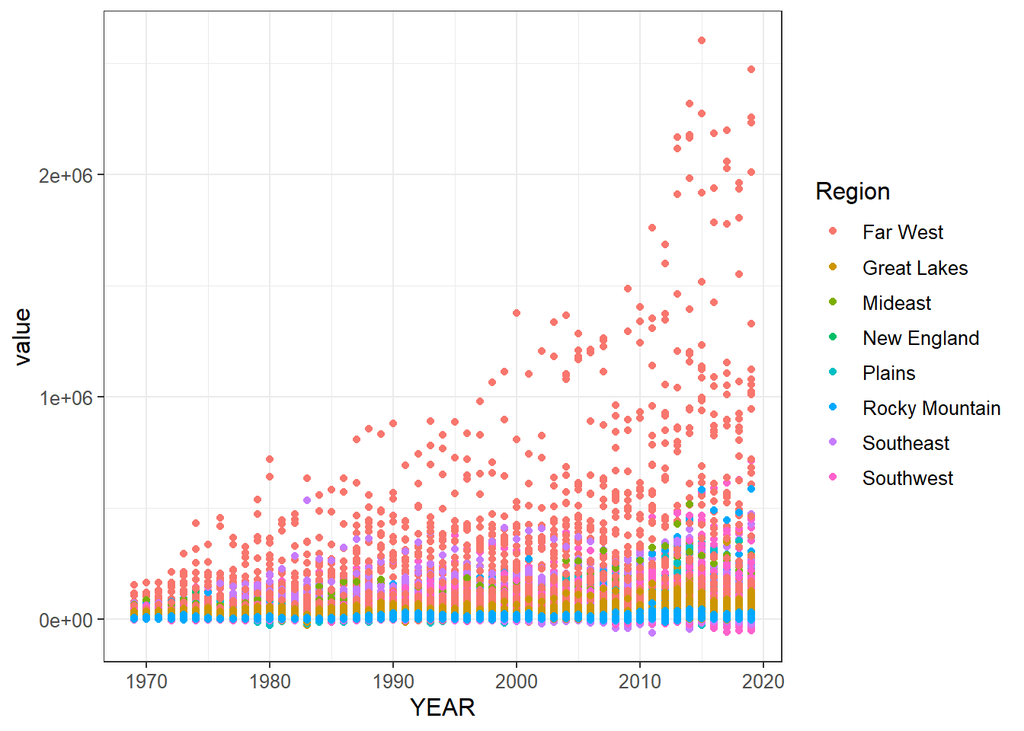

```r
farms %>%
  filter(Description == "Equals: Farm earnings",
         GEOID %in% unique(counties$GEOID)) %>%
  ggplot(.) +
  geom_point(aes(x = YEAR, y = value, color = Region)) +
  project_theme
```

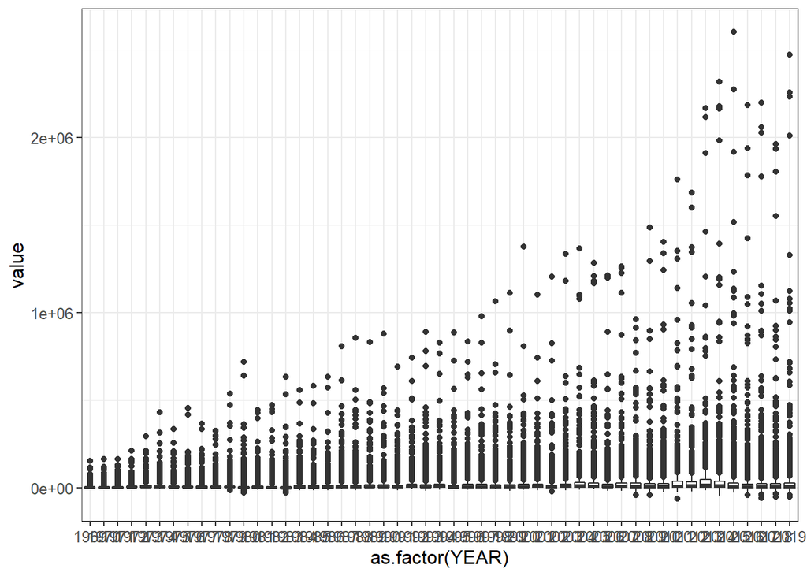

```r
farms %>%
  filter(Description == "Equals: Farm earnings",
         GEOID %in% unique(counties$GEOID)) %>%
  ggplot(.) +
  geom_boxplot(aes(x = as.factor(YEAR), y = value)) +
  project_theme
```

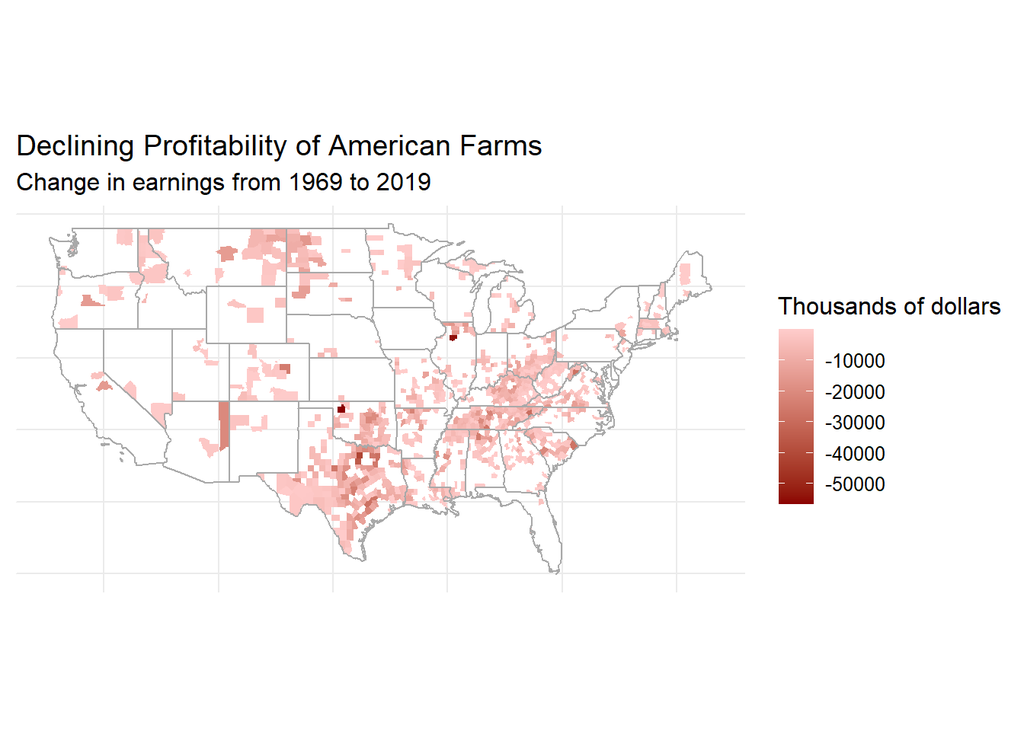

```r
delta_earnings <- farms %>%
  filter(Description == "Equals: Farm earnings",
         GEOID %in% unique(counties$GEOID)) %>%
  group_by(GEOID) %>%
  summarize(DELTA = value[YEAR == max(YEAR)] - value[YEAR == min(YEAR)])
delta_earnings <- merge(counties, delta_earnings, by = "GEOID")
delta_earnings$LOSERS <- ifelse(delta_earnings$DELTA < 0, "Decrease", "Increase")

ggplot() +
  geom_sf(data = delta_earnings %>% filter(LOSERS == "Decrease"), aes(fill = DELTA), color = "transparent") +
  geom_sf(data = states, fill = "transparent", color = "dark gray") +
  map_theme +
  scale_fill_gradient(low = "dark red", high = "#FFCCCB") +
  labs(title = "Declining Profitability of American Farms",
       subtitle = "Change in earnings from 1969 to 2019",
      fill = "Thousands of dollars") +
  theme(legend.position = "right")
```

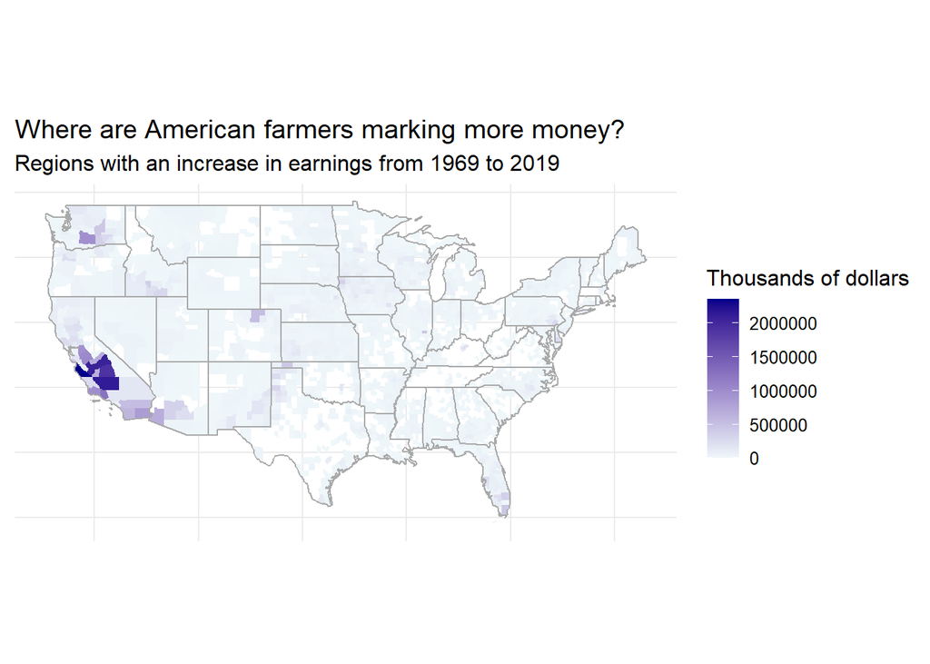

```r
ggplot() +
  geom_sf(data = delta_earnings %>% filter(LOSERS == "Increase"), aes(fill = DELTA), color = "transparent") +
  geom_sf(data = states, fill = "transparent", color = "dark gray") +
  map_theme +
  scale_fill_gradient(low = "#eff7fa", high = "dark blue") +
  labs(title = "Where are American farmers marking more money?",
       subtitle = "Regions with an increase in earnings from 1969 to 2019",
      fill = "Thousands of dollars") +
  theme(legend.position = "right")
```

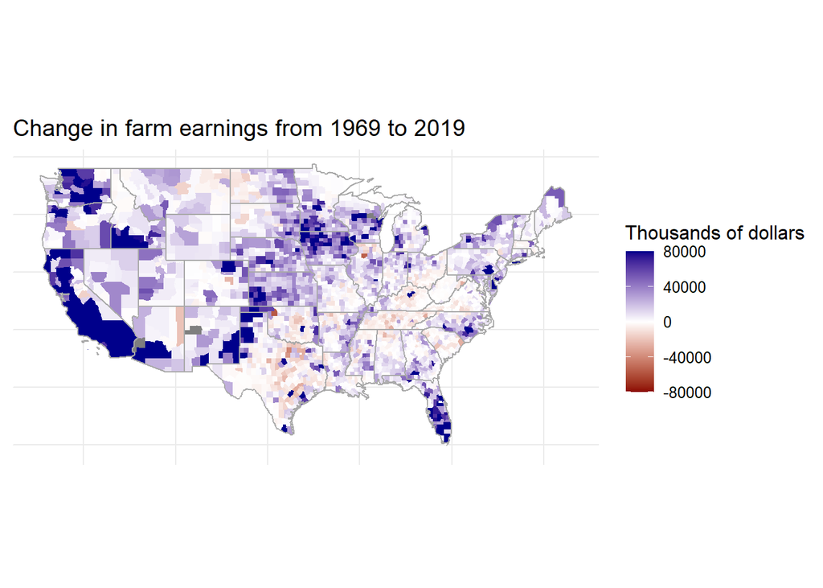

```r
delta_earnings$DELTA_CROP <- ifelse(delta_earnings$DELTA > 80000, 80000, delta_earnings$DELTA)
ggplot() +
  geom_sf(data = delta_earnings, aes(fill = DELTA_CROP), color = "transparent") +
  geom_sf(data = states, fill = "transparent", color = "dark gray") +
  map_theme +
  scale_fill_gradient2(low = "dark red", mid = "white", high = "dark blue", limits = c(-80000, 80000)) +
  labs(title = "Change in farm earnings from 1969 to 2019",
      fill = "Thousands of dollars") +
  theme(legend.position = "right")
```

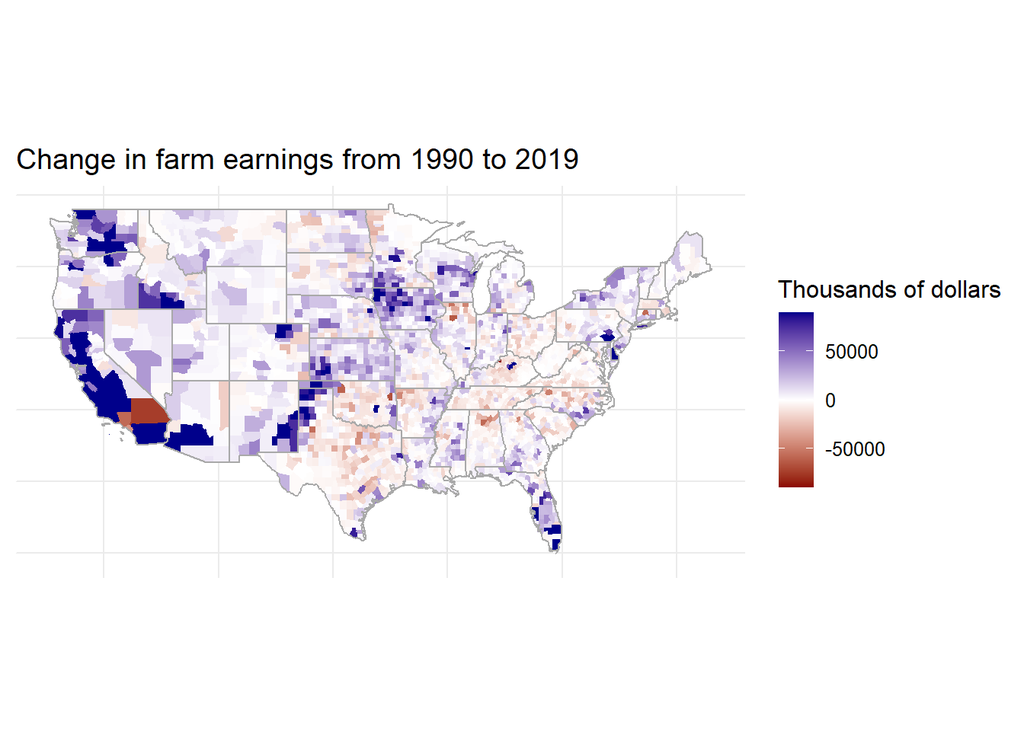

```r
delta_earnings <- farms %>%
  filter(Description == "Equals: Farm earnings",
         GEOID %in% unique(counties$GEOID)) %>%
  group_by(GEOID) %>%
  summarize(DELTA = value[YEAR == max(YEAR)] - value[YEAR == 1990])
delta_earnings <- merge(counties, delta_earnings, by = "GEOID")
delta_earnings$LOSERS <- ifelse(delta_earnings$DELTA < 0, "Decrease", "Increase")

delta_earnings$DELTA_CROP <- ifelse(delta_earnings$DELTA > 90000, 90000, delta_earnings$DELTA)
ggplot() +
  geom_sf(data = delta_earnings, aes(fill = DELTA_CROP), color = "transparent") +
  geom_sf(data = states, fill = "transparent", color = "dark gray") +
  map_theme +
  scale_fill_gradient2(low = "dark red", mid = "white", high = "dark blue", limits = c(-90000, 90000)) +
  labs(title = "Change in farm earnings from 1990 to 2019",
      fill = "Thousands of dollars") +
  theme(legend.position = "right")
```

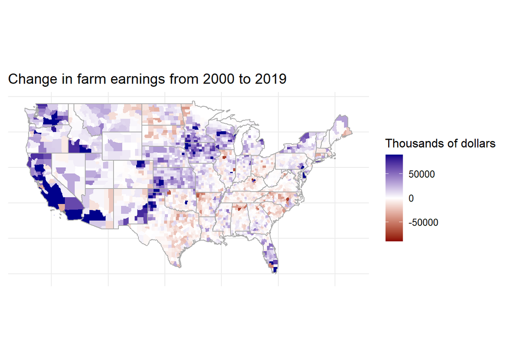

```r
delta_earnings <- farms %>%
  filter(Description == "Equals: Farm earnings",
         GEOID %in% unique(counties$GEOID)) %>%
  group_by(GEOID) %>%
  summarize(DELTA = value[YEAR == max(YEAR)] - value[YEAR == 2000])
delta_earnings <- merge(counties, delta_earnings, by = "GEOID")
delta_earnings$LOSERS <- ifelse(delta_earnings$DELTA < 0, "Decrease", "Increase")

delta_earnings$DELTA_CROP <- ifelse(delta_earnings$DELTA > 90000, 90000, delta_earnings$DELTA)
ggplot() +
  geom_sf(data = delta_earnings, aes(fill = DELTA_CROP), color = "transparent") +
  geom_sf(data = states, fill = "transparent", color = "dark gray") +
  map_theme +
  scale_fill_gradient2(low = "dark red", mid = "white", high = "dark blue", limits = c(-90000, 90000)) +
  labs(title = "Change in farm earnings from 2000 to 2019",
      fill = "Thousands of dollars") +
  theme(legend.position = "right")
```

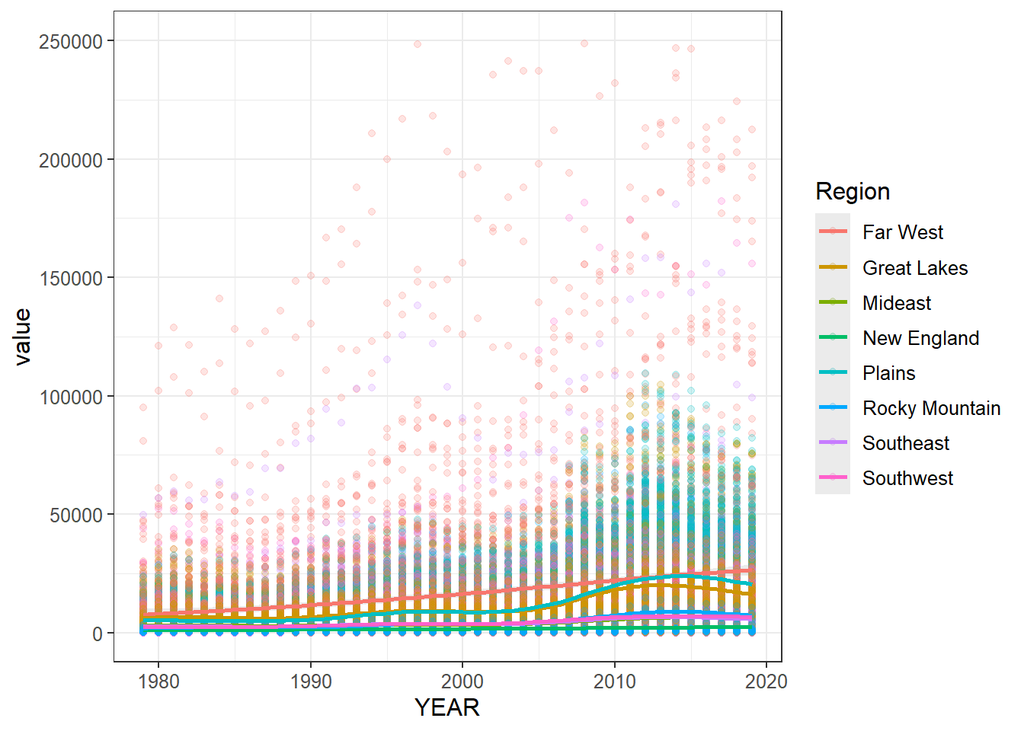

```r
# need to standardize by county size or something
farms %>%
  filter(Description == "Fertilizer and lime (incl. ag. chemicals 1978-fwd.)",
         GEOID %in% unique(counties$GEOID),
         YEAR > 1978) %>%
  ggplot(.) +
  geom_point(aes(x = YEAR, y = value, color = Region), alpha = 0.2) +
  geom_smooth(aes(x = YEAR, y = value, group = Region, color = Region), alpha = 0.2) +
  project_theme +
  ylim(c(0,250000)) # many above this threshold
```

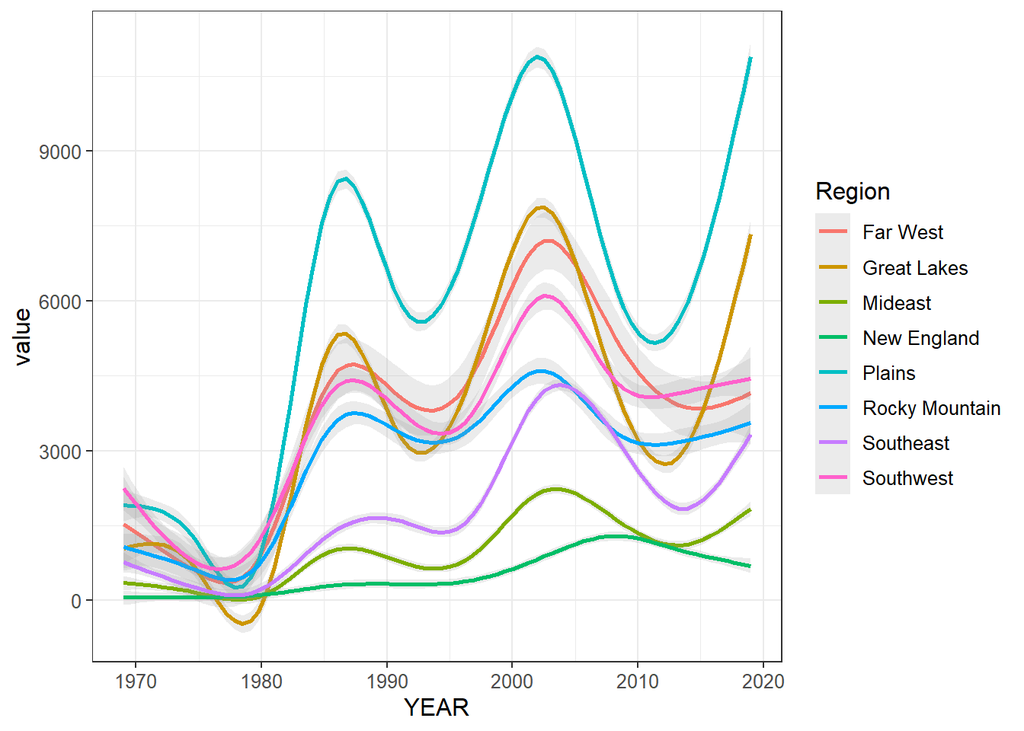

```r
# need to standardize by county size or something
farms %>%
  filter(Description == "Government payments",
         GEOID %in% unique(counties$GEOID)) %>%
  ggplot(.) +
  # geom_point(aes(x = YEAR, y = value, color = Region), alpha = 0.2) +
  geom_smooth(aes(x = YEAR, y = value, group = Region, color = Region), alpha = 0.2) +
  project_theme
```

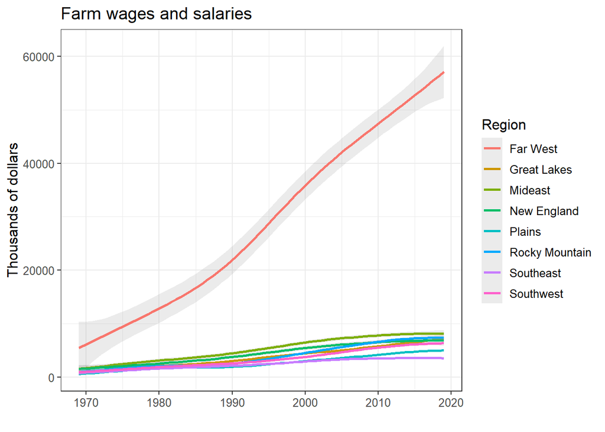

```r
# need to standardize by county size or something
farms %>%
  filter(Description == "Plus: Farm wages and salaries",
         GEOID %in% unique(counties$GEOID)) %>%
  ggplot(.) +
  # geom_point(aes(x = YEAR, y = value, color = Region), alpha = 0.2) +
  geom_smooth(aes(x = YEAR, y = value, group = Region, color = Region), alpha = 0.2) +
  project_theme +
  labs(y = "Thousands of dollars",
       x = "",
       title = "Farm wages and salaries")
```

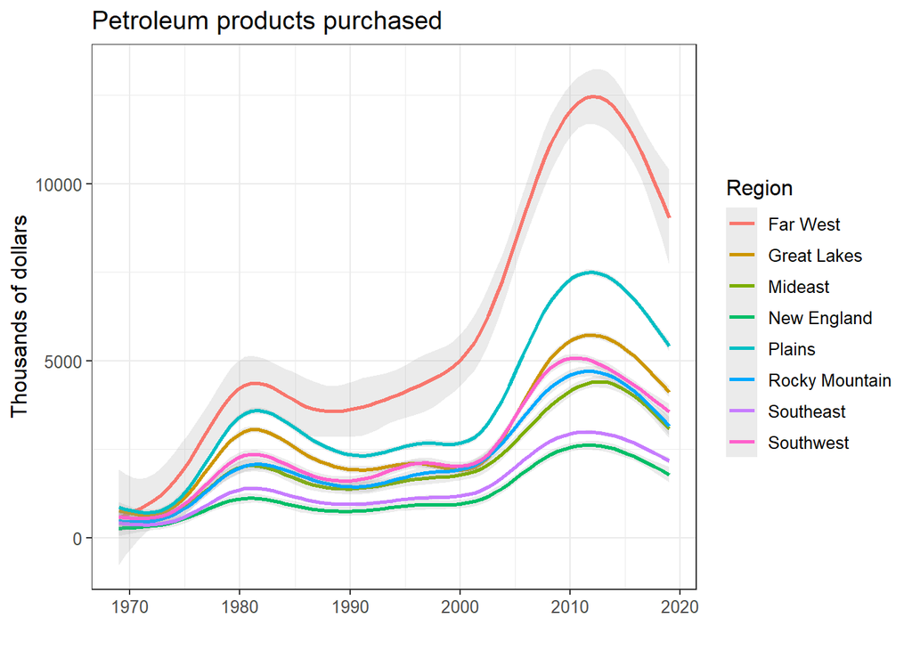

```r
# need to standardize by county size or something
farms %>%
  filter(Description == "Petroleum products purchased" ,
         GEOID %in% unique(counties$GEOID)) %>%
  ggplot(.) +
  # geom_point(aes(x = YEAR, y = value, color = Region), alpha = 0.2) +
  geom_smooth(aes(x = YEAR, y = value, group = Region, color = Region), alpha = 0.2) +
  project_theme +
  labs(y = "Thousands of dollars",
       x = "",
       title = "Petroleum products purchased")
```

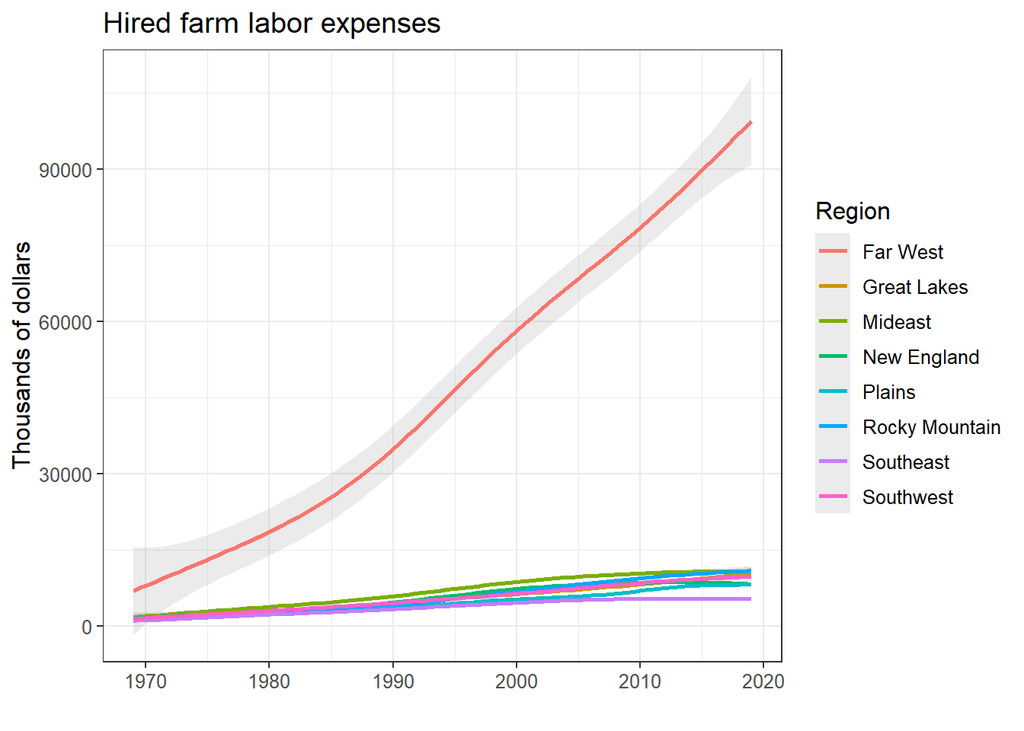

```r
# need to standardize by county size or something
farms %>%
  filter(Description == "Hired farm labor expenses 2/"  ,
         GEOID %in% unique(counties$GEOID)) %>%
  ggplot(.) +
  # geom_point(aes(x = YEAR, y = value, color = Region), alpha = 0.2) +
  geom_smooth(aes(x = YEAR, y = value, group = Region, color = Region), alpha = 0.2) +
  project_theme +
  labs(y = "Thousands of dollars",
       x = "",
       title = "Hired farm labor expenses")
```

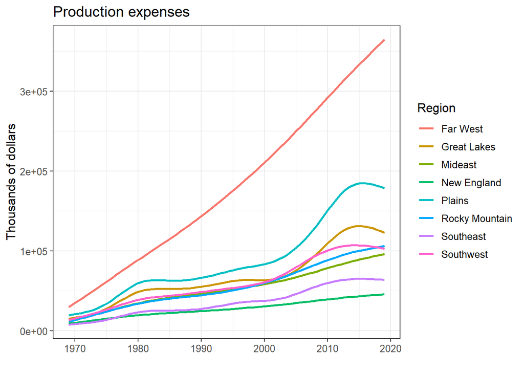

```r
# need to standardize by county size or something
farms %>%
  filter(Description == "Less: Production expenses"  ,
         GEOID %in% unique(counties$GEOID)) %>%
  ggplot(.) +
  # geom_point(aes(x = YEAR, y = value, color = Region), alpha = 0.2) +
  geom_smooth(aes(x = YEAR, y = value, group = Region, color = Region), alpha = 0.2, se=F) +
  project_theme +
  labs(y = "Thousands of dollars",
       x = "",
       title = "Production expenses")
```